# J Conklin Reproducible Research Course Project 1

This meets the requirements of course project 1 to produce an R markdown file containing analysis of the number of steps taken in five minute intervals over nearly two months.

First, let’s load the data and format the date variable.

```r
     activity <- read.table("./activity.csv",sep=",",header=TRUE,na.strings="NA")

     activity$date <- as.Date(as.character(activity$date),"%Y-%m-%d")

     row.names(activity) <- NULL

     activity$index <- seq(1,length(activity$steps),1)
```

Next, sum the steps by five minute interval over all days and construct a histogram

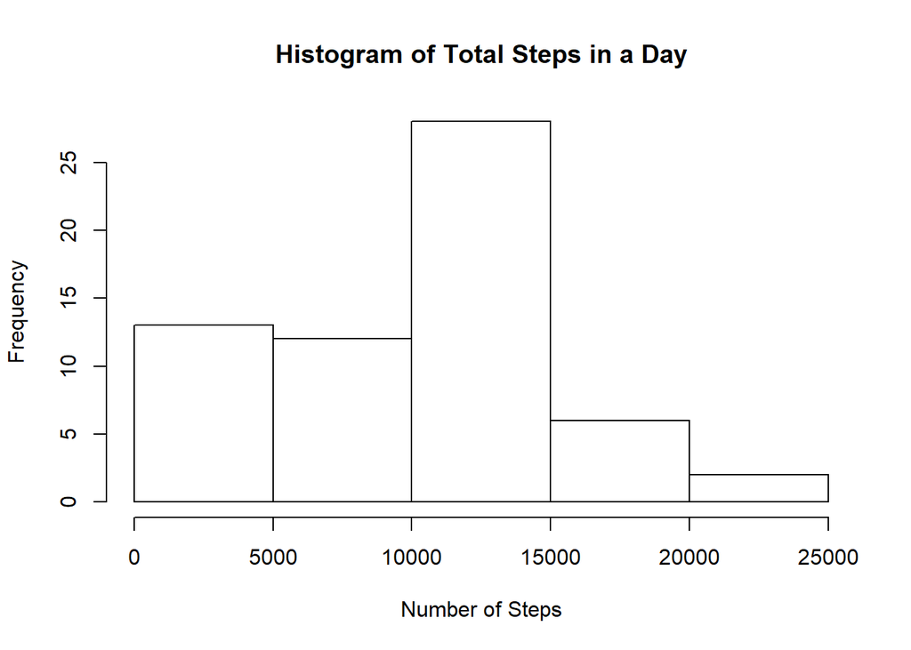

```r
   steps <- with(activity,tapply(steps,date,sum,na.rm = TRUE))

   hist(steps,main = "Histogram of Total Steps in a Day",xlab = "Number of Steps")
```

Next, compute the mean and median number of steps over all five minute intervals over all days. Exclude missing values.

```r
   mean(activity$steps,na.rm = TRUE)
```

```
## [1] 37.3826
```

```r
   median(activity$steps,na.rm = TRUE)
```

```
## [1] 0
```

Next, average the steps by five minute interval over all days. Exclude missing values. Format the file of averages to faciliate plotting.

```r
   avg_steps <- with(activity,tapply(steps,interval,mean,na.rm=TRUE))

   avg_steps <- data.frame(row.names(avg_steps),avg_steps)

   colnames(avg_steps) <- c("Interval","Average_Steps")

   avg_steps$Interval <- as.character(avg_steps$Interval)

   row.names(avg_steps) <- NULL
```

Next, plot the averages.

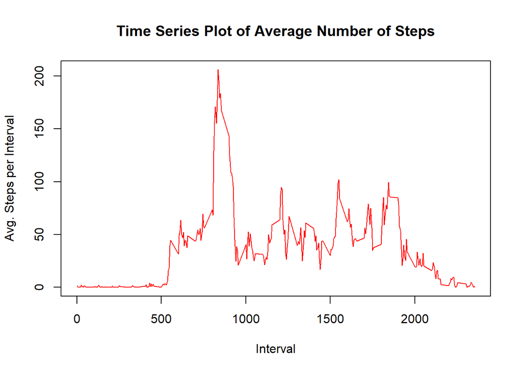

```r
   plot(avg_steps$Interval,avg_steps$Average_Steps,type="l",col="red",
        main= "Time Series Plot of Average Number of Steps",
        xlab="Interval",ylab="Avg. Steps per Interval",
        ylim=c(min(avg_steps$Average_Steps),max(avg_steps$Average_Steps)))
```

Next, find and print the five minute interval with the largest average number of steps.

```r
  avg_steps$Interval[avg_steps$Average_Steps == max(avg_steps$Average_Steps)]
```

```
## [1] "835"
```

Next, find the rows where the number of steps is a missing value. Merge the file of steps data with file of average number of steps by five minute interval. Convert interval variable from factor to numeric to facilitate merge.

```r
   table(is.na(activity$steps))
```

```
##
## FALSE  TRUE
## 15264  2304
```

```r
   avg_steps$Interval <- as.numeric(avg_steps$Interval)

   activity_impute <- merge(activity,avg_steps,by.x = "interval",
                            by.y = "Interval")

   rm(avg_steps)
```

Next, impute for missing values by substituting average number of steps for a given five minute interval. Compute the mean and median number of steps over all five minute intervals over all days after imputation is complete.

```r
   activity_impute$steps[is.na(activity_impute$steps)] <-
                         activity_impute$Average_Steps[is.na(activity_impute$steps)]

   mean(activity_impute$steps,na.rm = TRUE)
```

```
## [1] 37.3826
```

```r
   median(activity_impute$steps,na.rm = TRUE)
```

```
## [1] 0
```

Next, sum the steps by five minute interval over all days and construct a histogram after imputation is complete

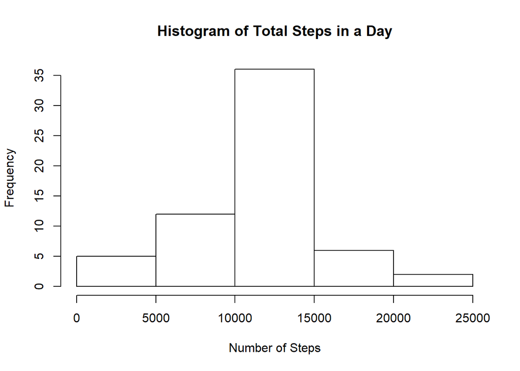

```r
   steps_impute <- with(activity_impute,tapply(steps,date,sum,na.rm = TRUE))

   hist(steps_impute,main = "Histogram of Total Steps in a Day",xlab = "Number of Steps")
```

```r
   rm(steps_impute)
```

Next, create a new variable for whether current date falls on a weekday or on a weekend. Split the file of steps data after imputation is complete so one piece is just for weekdays and the other is just for weekends.

```r
   activity_impute$period <- ifelse(weekdays(activity_impute$date) %in%
                                    c("Monday","Tuesday","Wednesday","Thursday","Friday"),
                                    "Weekdays","Weekends")

   avg_weekdays_impute <- with(subset(activity_impute,activity_impute$period == "Weekdays"),
                                      tapply(steps,interval,mean,na.rm=TRUE))

   avg_weekends_impute <- with(subset(activity_impute,activity_impute$period == "Weekends"),
                                      tapply(steps,interval,mean,na.rm=TRUE))
```

Next, format the two files resulting from the split to facilitate later creation of panel plot comparing trends over weekdays to trends over weekends.

```r
   avg_weekdays_impute <- data.frame(row.names(avg_weekdays_impute),avg_weekdays_impute)

   colnames(avg_weekdays_impute) <- c("Interval","Average_Steps")

   row.names(avg_weekdays_impute) <- NULL

   avg_weekdays_impute$Period <- "Weekdays"

   avg_weekends_impute <- data.frame(row.names(avg_weekends_impute),avg_weekends_impute)

   colnames(avg_weekends_impute) <- c("Interval","Average_Steps")

   row.names(avg_weekends_impute) <- NULL

   avg_weekends_impute$Period <- "Weekends"
```

Next, combine the two split pieces back into a single file. Convert the interval variable to numeric format to facilitate later panel plot. Re-sort the data to its original order.

```r
   avg_impute_steps <- rbind(avg_weekdays_impute,avg_weekends_impute)

   avg_impute_steps$Interval <- as.numeric(as.character(avg_impute_steps$Interval))

   activity_impute <- activity_impute[order(activity_impute$index),]

   rm(avg_weekdays_impute,avg_weekends_impute)
```

Next, call ggplot2 and create panel plot comparing trends in steps data over weekdays to trends over weekends. Delete R objects no longer needed.

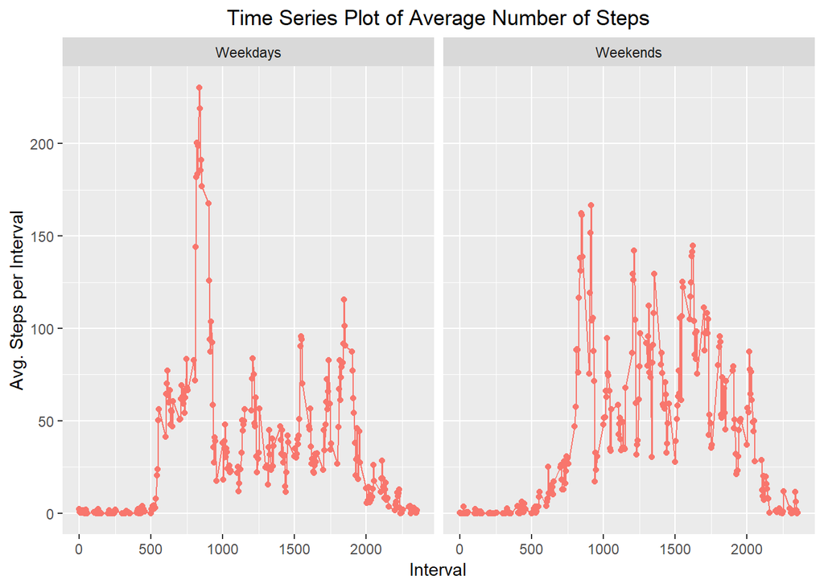

```r
   library(ggplot2)

   bc <- qplot(Interval,Average_Steps,data = avg_impute_steps, facets = . ~ Period,
               main= "Time Series Plot of Average Number of Steps", col = "red",
               xlab="Interval",ylab="Avg. Steps per Interval",
               ylim=c(min(avg_impute_steps$Average_Steps),
                      max(avg_impute_steps$Average_Steps)))

   bc + theme(plot.title = element_text(hjust = 0.5)) + theme(legend.position = "none") +
        geom_line(linetype = "solid")
```

```r
   rm(activity,activity_impute,avg_impute_steps)
```

End of markdown file for Reproducible Research course project 1